# Resultados UCLUST

### UCLUST con id = 99.9%

Estas graficas representan las secuencias de Genoma completo del virus del Dengue analizadas con UCLUST con id= 99.9% y se compara las secuencias similares y disimilares a este valor id.

### Secuencias similares al 99.9%

|  | N_Accesion | gi | Title | Serotype | Genotype | Gene | Size_sequence | Country | Location | Year | Month | lat_country | lon_country | locationtype_country | formatted_country | lat_location | lon_location | locationtype_location | formatted_location | Comments |
| --- | --- | --- | --- | --- | --- | --- | --- | --- | --- | --- | --- | --- | --- | --- | --- | --- | --- | --- | --- | --- |
| 1381 | FJ639670 | 221071158 | Dengue_virus_1_isolate_DENV_1_KH_BID_V1979_2001_complete_genome | DENV_1 | NA | Complete_Genome | 10693 | Cambodia | PHP | 2001 | NA | 12.565679 | 104.99096 | APPROXIMATE | Cambodia | NA | NA | NA | NA | Cambodia_PHP_cell_supernatant_2001_passage_history_AP61_passage_number_unknown_cohort_population_Dengue_Surveillance |
| 3784 | JF937615 | 332959477 | Dengue_virus_1_isolate_DENV_1_VN_BID_V4062_2008_complete_genome | DENV_1 | NA | Complete_Genome | 10448 | Viet Nam | South Viet Nam | 2008 | NA | 14.058324 | 108.27720 | APPROXIMATE | Vietnam | 14.058324 | 108.277199 | APPROXIMATE | Vietnam | Viet_Nam_South_plasma_2008_cohort_population_MD |
| 98 | AY708047 | 56698931 | Dengue_virus_type_1_strain_D1Myanmar059_01_polyprotein_gene_complete_cds | DENV_1 | NA | Complete_Genome | 10614 | Myanmar | NA | NA | NA | 21.916221 | 95.95597 | APPROXIMATE | Myanmar (Burma) | NA | NA | NA | NA | Myanmar |
| 1293 | FJ461303 | 217302380 | Dengue_virus_1_isolate_DENV_1_VN_BID_V971_2007_complete_genome | DENV_1 | NA | Complete_Genome | 10691 | Viet Nam | South Viet Nam | 2007 | NA | 14.058324 | 108.27720 | APPROXIMATE | Vietnam | 14.058324 | 108.277199 | APPROXIMATE | Vietnam | Viet_Nam_South_plasma_2007_cohort_population_FG |
| 1124 | FJ384655 | 211908643 | Dengue_virus_1_isolate_DF01_HUB01021093_complete_genome | DENV_1 | NA | Complete_Genome | 10735 | Brazil | NA | NA | NA | -14.235004 | -51.92528 | APPROXIMATE | Brazil | NA | NA | NA | NA | Brazil_plasma |
| 2805 | FJ898401 | 228540178 | Dengue_virus_1_isolate_DENV_1_VN_BID_V2864_2006_complete_genome | DENV_1 | NA | Complete_Genome | 10690 | Viet Nam | South Viet Nam | 2006 | NA | 14.058324 | 108.27720 | APPROXIMATE | Vietnam | 14.058324 | 108.277199 | APPROXIMATE | Vietnam | Viet_Nam_South_plasma_2006_cohort_population_MD |
| 1122 | FJ373305 | 209976533 | Dengue_virus_1_isolate_DENV_1_VN_BID_V1500_2006_complete_genome | DENV_1 | NA | Complete_Genome | 10690 | Viet Nam | South Viet Nam | 2006 | NA | 14.058324 | 108.27720 | APPROXIMATE | Vietnam | 14.058324 | 108.277199 | APPROXIMATE | Vietnam | Viet_Nam_South_plasma_2006_cohort_population_FG |
| 2806 | FJ898400 | 228540147 | Dengue_virus_1_isolate_DENV_1_VN_BID_V2863_2006_complete_genome | DENV_1 | NA | Complete_Genome | 10688 | Viet Nam | South Viet Nam | 2006 | NA | 14.058324 | 108.27720 | APPROXIMATE | Vietnam | 14.058324 | 108.277199 | APPROXIMATE | Vietnam | Viet_Nam_South_plasma_2006_cohort_population_MD |
| 2808 | FJ898398 | 228540090 | Dengue_virus_1_isolate_DENV_1_VN_BID_V2861_2006_complete_genome | DENV_1 | NA | Complete_Genome | 10688 | Viet Nam | South Viet Nam | 2006 | NA | 14.058324 | 108.27720 | APPROXIMATE | Vietnam | 14.058324 | 108.277199 | APPROXIMATE | Vietnam | Viet_Nam_South_plasma_2006_cohort_population_MD |
| 2810 | FJ898396 | 228540033 | Dengue_virus_1_isolate_DENV_1_VN_BID_V2858_2006_complete_genome | DENV_1 | NA | Complete_Genome | 10719 | Viet Nam | South Viet Nam | 2006 | NA | 14.058324 | 108.27720 | APPROXIMATE | Vietnam | 14.058324 | 108.277199 | APPROXIMATE | Vietnam | Viet_Nam_South_plasma_2006_cohort_population_MD |

[output cut: 990 more lines]

**Tabla 1.** Datos del virus del Dengue que reportan el Genoma Completo y son 99.9% similares en sus secuencias. De 3.884 secuencias de genoma completo, 3.276, es decir, alrededor del 84% de las secuecias son 99.9% iguales.

### Secuencias disimilares al 99.9%

|  | N_Accesion | gi | Title | Serotype | Genotype | Gene | Size_sequence | Country | Location | Year | Month | lat_country | lon_country | locationtype_country | formatted_country | lat_location | lon_location | locationtype_location | formatted_location | Comments |
| --- | --- | --- | --- | --- | --- | --- | --- | --- | --- | --- | --- | --- | --- | --- | --- | --- | --- | --- | --- | --- |
| 2807 | FJ898399 | 228540118 | Dengue_virus_1_isolate_DENV_1_VN_BID_V2862_2006_complete_genome | DENV_1 | NA | Complete_Genome | 10690 | Viet Nam | South Viet Nam | 2006 | NA | 14.058324 | 108.27720 | APPROXIMATE | Vietnam | 14.058324 | 108.27720 | APPROXIMATE | Vietnam | Viet_Nam_South_plasma_2006_cohort_population_MD |
| 2809 | FJ898397 | 228540061 | Dengue_virus_1_isolate_DENV_1_VN_BID_V2860_2006_complete_genome | DENV_1 | NA | Complete_Genome | 10680 | Viet Nam | South Viet Nam | 2006 | NA | 14.058324 | 108.27720 | APPROXIMATE | Vietnam | 14.058324 | 108.27720 | APPROXIMATE | Vietnam | Viet_Nam_South_plasma_2006_cohort_population_MD |
| 1108 | FJ205883 | 206597913 | Dengue_virus_1_isolate_DENV_1_VN_BID_V1694_2007_complete_genome | DENV_1 | NA | Complete_Genome | 10690 | Viet Nam | South Viet Nam | 2007 | NA | 14.058324 | 108.27720 | APPROXIMATE | Vietnam | 14.058324 | 108.27720 | APPROXIMATE | Vietnam | Viet_Nam_South_plasma_2007_cohort_population_FG |
| 2818 | FJ898388 | 228539780 | Dengue_virus_1_isolate_DENV_1_VN_BID_V2848_2005_complete_genome | DENV_1 | NA | Complete_Genome | 10690 | Viet Nam | South Viet Nam | 2005 | NA | 14.058324 | 108.27720 | APPROXIMATE | Vietnam | 14.058324 | 108.27720 | APPROXIMATE | Vietnam | Viet_Nam_South_plasma_2005_cohort_population_MD |
| 1142 | FJ390388 | 209976571 | Dengue_virus_1_isolate_DENV_1_VN_BID_V1702_2007_complete_genome | DENV_1 | NA | Complete_Genome | 10690 | Viet Nam | South Viet Nam | 2007 | NA | 14.058324 | 108.27720 | APPROXIMATE | Vietnam | 14.058324 | 108.27720 | APPROXIMATE | Vietnam | Viet_Nam_South_plasma_2007_cohort_population_FG |
| 1140 | FJ390386 | 209976567 | Dengue_virus_1_isolate_DENV_1_VN_BID_V1686_2007_complete_genome | DENV_1 | NA | Complete_Genome | 10690 | Viet Nam | South Viet Nam | 2007 | NA | 14.058324 | 108.27720 | APPROXIMATE | Vietnam | 14.058324 | 108.27720 | APPROXIMATE | Vietnam | Viet_Nam_South_plasma_2007_cohort_population_FG |
| 2797 | FJ898409 | 228540419 | Dengue_virus_1_isolate_DENV_1_VN_BID_V2879_2006_complete_genome | DENV_1 | NA | Complete_Genome | 10684 | Viet Nam | South Viet Nam | 2006 | NA | 14.058324 | 108.27720 | APPROXIMATE | Vietnam | 14.058324 | 108.27720 | APPROXIMATE | Vietnam | Viet_Nam_South_plasma_2006_cohort_population_MD |
| 2801 | FJ898405 | 228540292 | Dengue_virus_1_isolate_DENV_1_VN_BID_V2871_2006_complete_genome | DENV_1 | NA | Complete_Genome | 10679 | Viet Nam | South Viet Nam | 2006 | NA | 14.058324 | 108.27720 | APPROXIMATE | Vietnam | 14.058324 | 108.27720 | APPROXIMATE | Vietnam | Viet_Nam_South_plasma_2006_cohort_population_MD |
| 2802 | FJ898404 | 228540262 | Dengue_virus_1_isolate_DENV_1_VN_BID_V2868_2006_complete_genome | DENV_1 | NA | Complete_Genome | 10689 | Viet Nam | South Viet Nam | 2006 | NA | 14.058324 | 108.27720 | APPROXIMATE | Vietnam | 14.058324 | 108.27720 | APPROXIMATE | Vietnam | Viet_Nam_South_plasma_2006_cohort_population_MD |
| 1068 | FJ182029 | 206597842 | Dengue_virus_1_isolate_DENV_1_VN_BID_V1658_2007_complete_genome | DENV_1 | NA | Complete_Genome | 10690 | Viet Nam | South Viet Nam | 2007 | NA | 14.058324 | 108.27720 | APPROXIMATE | Vietnam | 14.058324 | 108.27720 | APPROXIMATE | Vietnam | Viet_Nam_South_plasma_2007_cohort_population_FG |

[output cut: 598 more lines]

**Tabla 2.** Datos del virus del Dengue que reportan el Genoma Completo y son 99.9% Disimilares en sus secuencias. De 3.884 secuencias de genoma completo, 608 secuencias, es decir, alrededor del 16% de las secuecias son 99.9% desiiguales.

### Serotipos

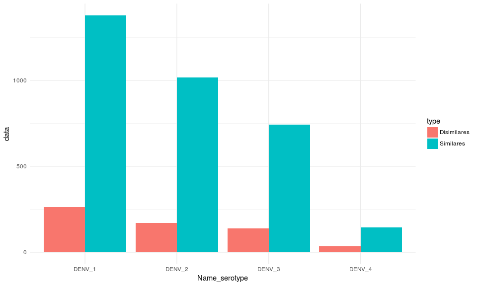

**Figura 1.** Numero de datos por serotipos para las secuencias Disimilares Vs Similares al 99.9%. La frecuencia de los serotipos para loas secuencias disimilares tiene la misma proporcion que la frecuencia de los serotipos para el total de las de genoma completo.

Genomas: DENV_4= 4%, DENV_3= 23%, DENV_2= 30%, DENV_1= 42%.

disimilares: DEN_4= 6%, DENV_3= 23%, DENV_2= 28%, DENV_1=43%.

### Paises

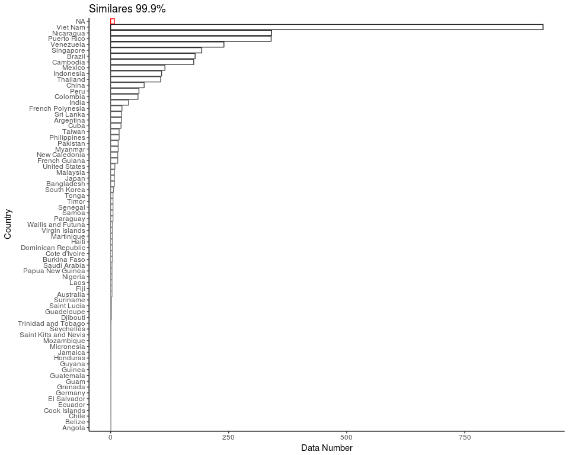

**Figura 2.** Paises para secuencias de Genoma con 99.9% de similaridad.

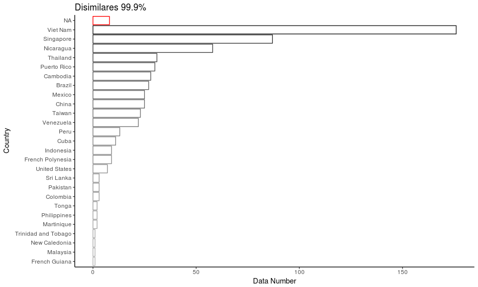

**Figura 3.** Paises para secuencias de Genoma con 99.9% de disimilaridad. De los 70 paises que se reportan con Genoma solo 26 paises tienen secuencias 99.9% disimilares. 11 paises asiaticos, 8 paises latinoamericanos y 7 islas.

- Los paises que fueron eliminados son:

[1] “Myanmar” “India” “Chile”  
[4] “Virgin Islands” “Angola” “Laos”  
[7] “Djibouti” “Cote d’Ivoire” “Haiti”  
[10] “Micronesia” “Seychelles” “Japan”  
[13] “El Salvador” “South Korea” “Germany”  
[16] “Saudi Arabia” “Argentina” “Burkina Faso”  
[19] “Suriname” “Guadeloupe” “Papua New Guinea”  
[22] “Guam” “Saint Kitts and Nevis” “Belize”  
[25] “Honduras” “Dominican Republic” “Jamaica”  
[28] “Nigeria” “Senegal” “Australia”  
[31] “Guinea” “Timor” “Samoa”  
[34] “Fiji” “Guatemala” “Grenada”  
[37] “Bangladesh” “Paraguay” “Wallis and Futuna”  
[40] “Saint Lucia” “Guyana” “Cook Islands”  
[43] “Ecuador” “Mozambique”

### Mapa-Mundi: Numero de casos reportados por paises

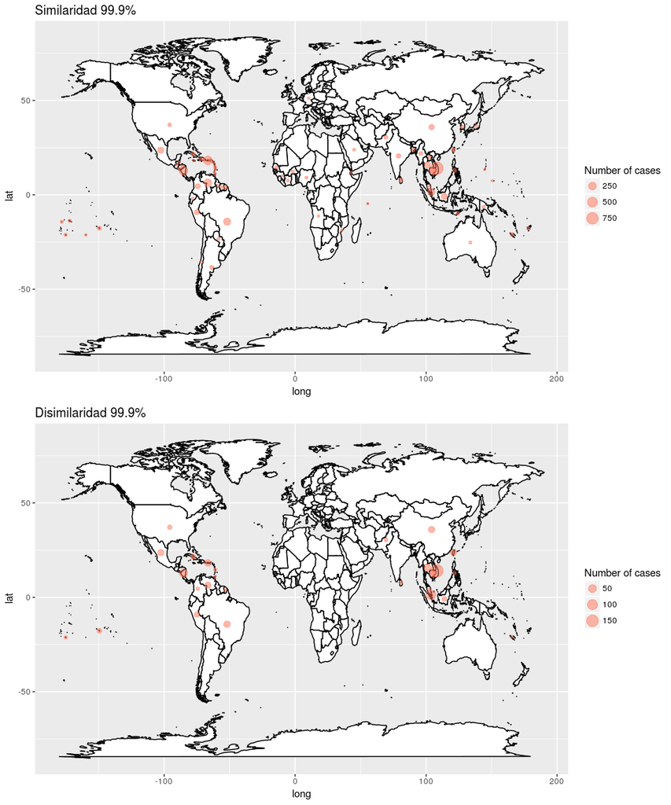

**Figura 4.**

### Mapa-mundi: Serotipos por paises

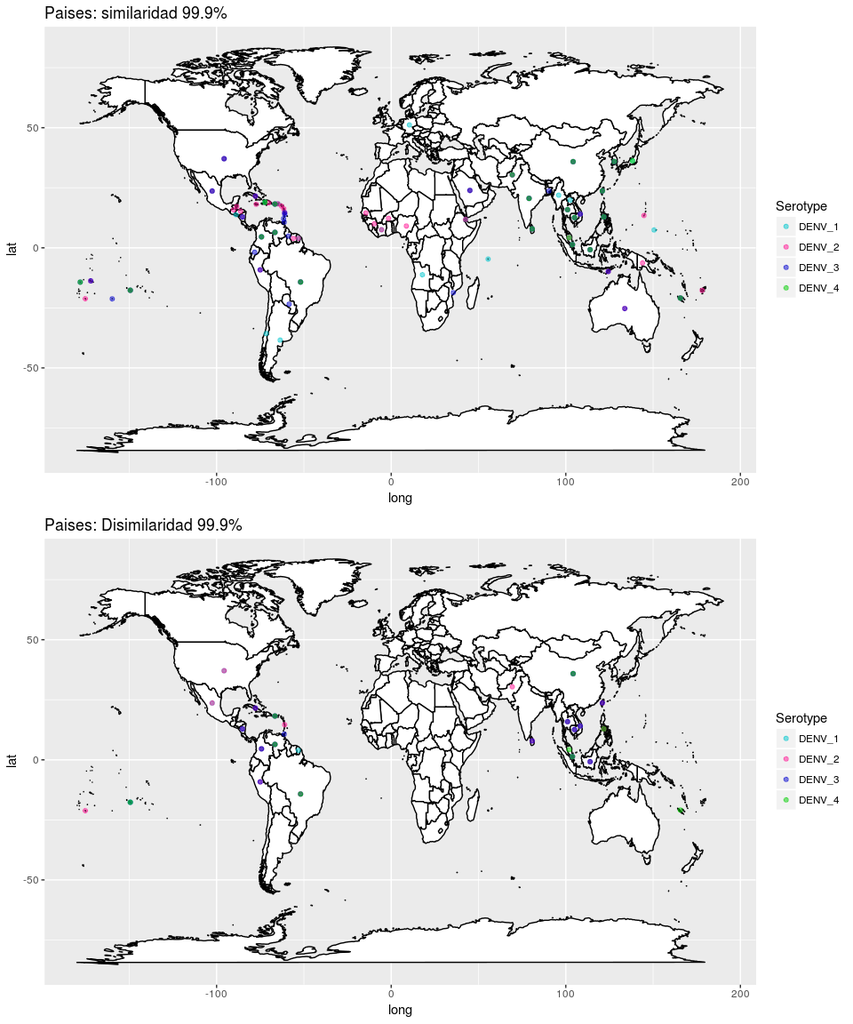

### Localidades: similaridad 99.9%

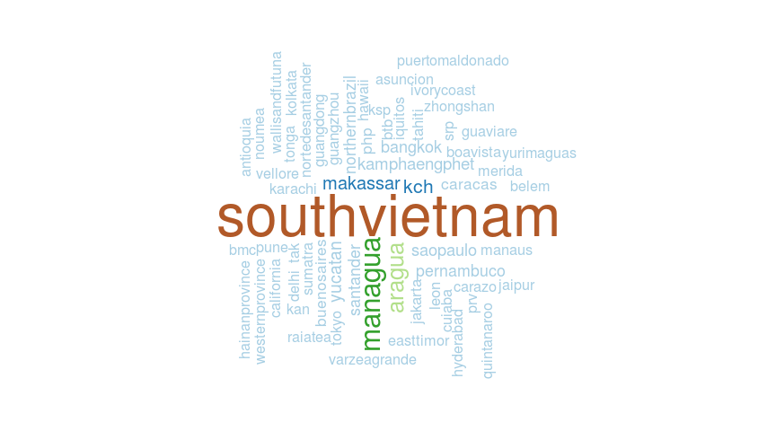

**Figura 6.** Nube de localidades para casos con secuecias del Genoma 99.9% identicas.

### Localidades: Disimilaridad 99.9%

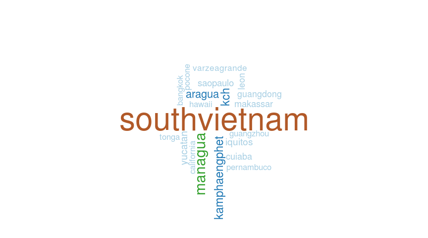

**Figura 7.** Nube de localidades para casos con secuencias del Genoma 99.9% Disimilares. En general tanto las secuencas similares como disimilares presentan las mismas cuatro localidades con mas reportadas que todos los datos de genoma

### Mapa-mundi localidades 99.9% similaridad

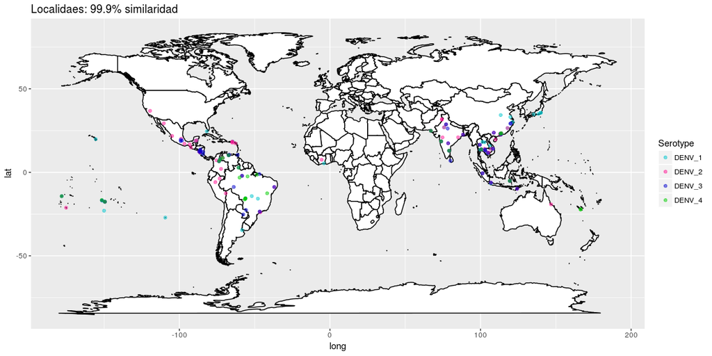

**Figura 8.** Localidades de casos con secuencias del genoma 99.9% similares.

### Mapa-mundi localidades 99.9% Disimilaridad

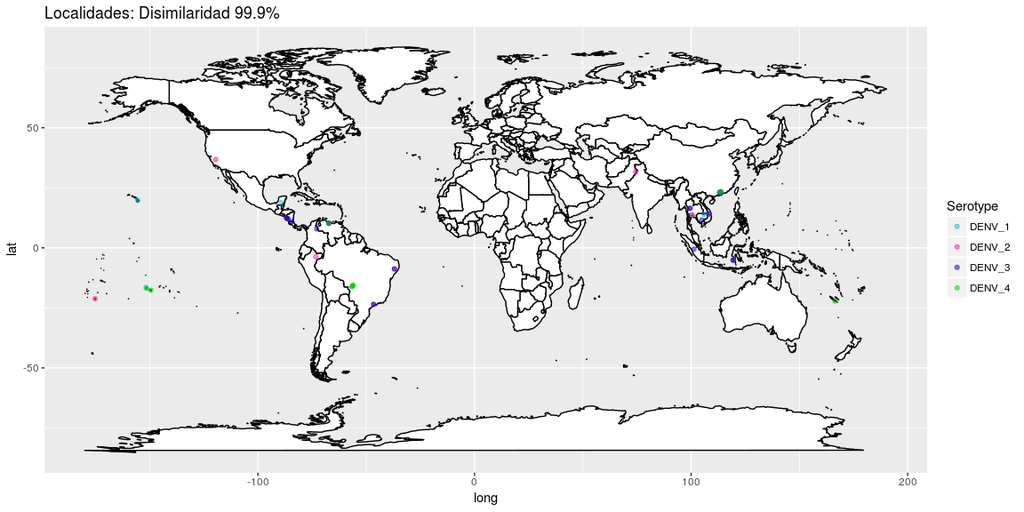

**Figura 9.** Localidades para casos con secuencias del genoma 99.9% disimilares.

- Colombia, Mexico, New Caledonia, Pakistan, Peru, Venezuela, y VietNam solo presenta una localidad.
- Cuba, Frech Guinea, Malasia, Martinique, Filipinas, Puerto Rico, Singapur, Sri Lanka, Taiwan, y Trinidad y Tobago no presentan localidades.

### Años: Similaridad 99.9%

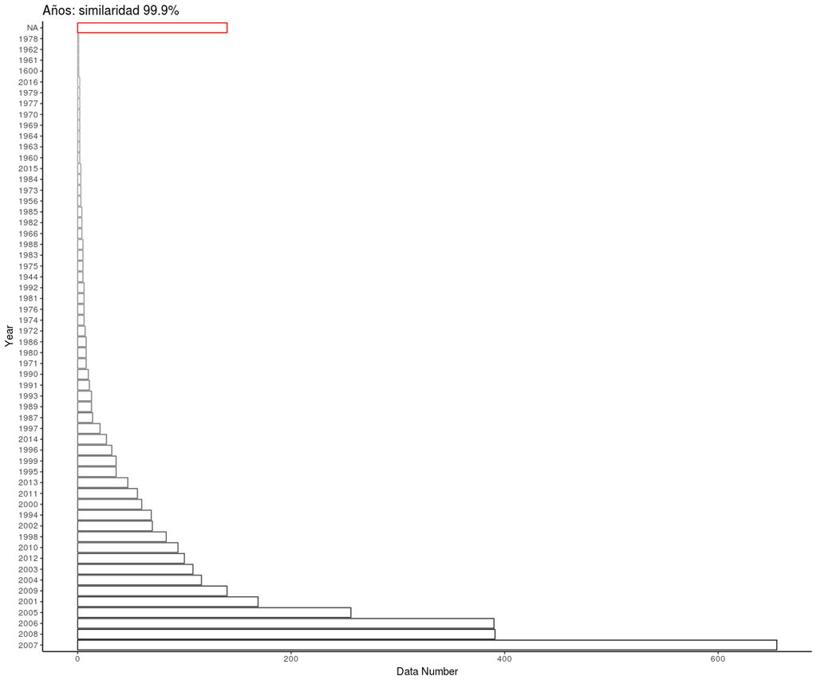

**Figura 10.** Años registrados para casos con secuencias 99.9% similares.

### Años: Disimilaridad 99.9%

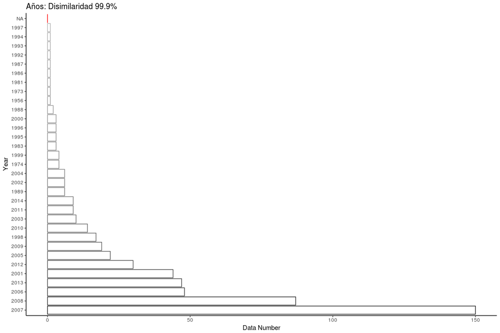

**Figura 11.** Años registrados para casos con secuencias 99.9% disimilares.

- Los años que fueron eliminados son todos años antiguos, la mayoria de los años 1900, siendo el años eliminado mas reciente 1991:

[1] “1991” “1990” “1944” “1985” “1972” “2015” “1600” “1976” “1971” “1960” “1982” “1963”

[13] “2016” “1980” “1969” “1984” “1964” “1977” “1966” “1970” “1979” “1975” “1978” “1961”

[25] “1962”

(Los años 2015 y 2016 no se toman en cuenta debido a que los registros para la fecha en que fue descargada la base de datos no representa el total de los registros para esos años)

### Frecuencia de los años reportados por cada pais: Similaridad 99.9%

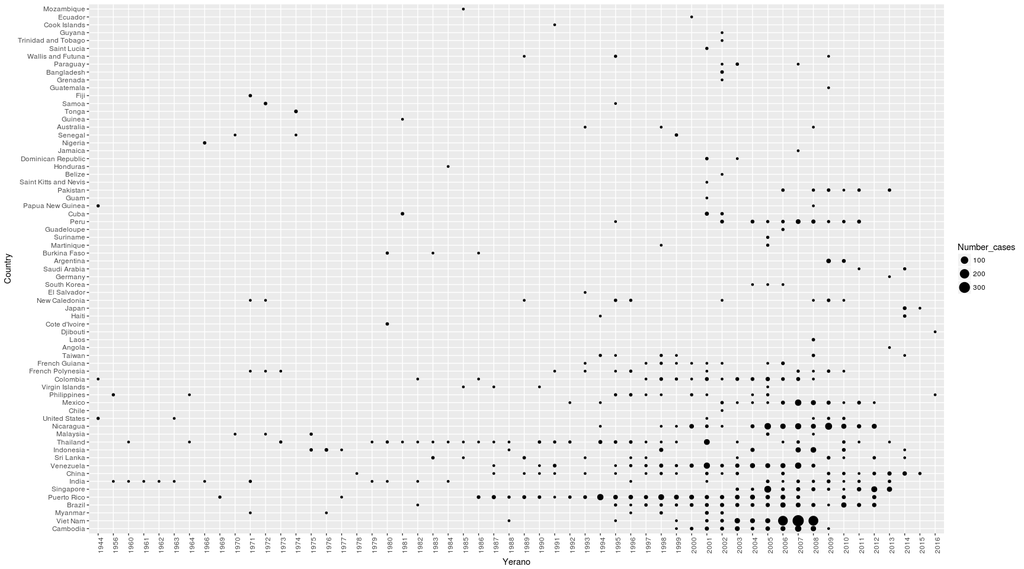

**Figura 12.** Frecuencia de los años reportados para cada pais en casos con 99.9% de similaridad.

### Frecuencia de los años reportados por cada pais: Disimilaridad 99.9%

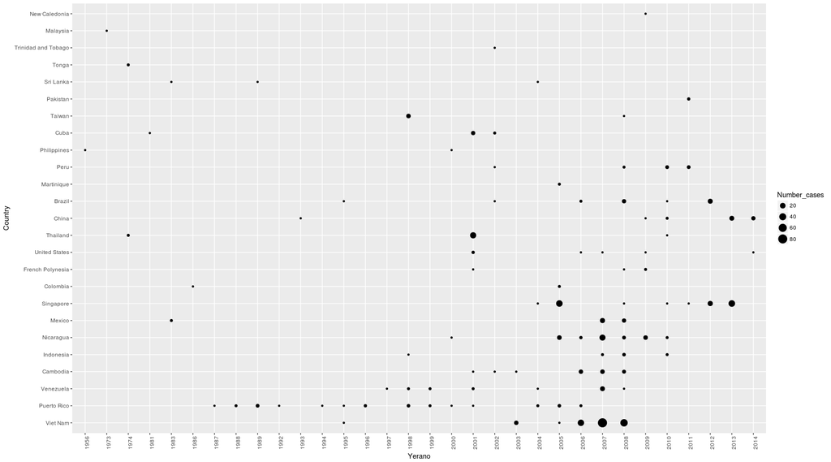

**Figura 12.** Frecuencia de los años reportados para cada pais en casos con 99.9% de disimilaridad.

### Pais, localidad y año: Disimilaridad 99.9%

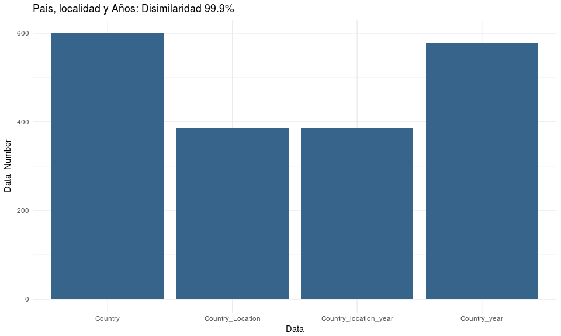

**Figura 13.** Frecuencia de los datos con disimilaridad del 99.9% que contienen: 1. Pais, 2. Pais y Localidad, 3. Pais, Localidad y año, 4. Pais y año.